# cyclist

Franklin Aguilar

2/17/2022

# Ciclismo Casual y Premium

## Objetivo del analisis

El objetivo de este análisis es descubrir los patrones de uso de los consumidores casuales de los premium. De esta forma se podría saber bajo que condiciones el consumidor elige una suscripción en comparación a otra y tratar de aplicar esas ideas para convencer a un usuario casual de se suscriba a la versión premium.

¿Lo lograre? No tengo idea, pero vamos con todos los huevos a describirlo!!!

## Sobre la data

La data de este proyecto contiene la información de los viajes de los usuarios del servicio de alquiler de bicicletas divvy entre los meses de enero de 2021 y enero de 2022. La data es de origen publico y es posible descargarlo del siguiente enlace:

https://divvy-tripdata.s3.amazonaws.com/index.html

## Primeros Pasos

Pero primero trabajemos en chiquito. Vamos a importar la data del mes de enero del 2021.

```r
setwd("/Users/franklinaguilar/Documents/Github/cyclist")
library(tidyverse)
library(dplyr)
data_1 <- read.csv("202101-divvy-tripdata.csv")
```

Quitamos filas con contenido vacio. Solo voy a trabajar con 2 columnas, asi que me voy a concentrar esas.

Fuente: https://www.diegocalvo.es/eliminar-na-o-valores-nulos-en-r/

```r
data_1 <- data_1[!is.na(data_1$ended_at),]
data_1 <- data_1[!is.na(data_1$started_at),]
```

Al parecer esa columnas están bien rellenada

> Google me pide hacer lo siguiente:
> 6. Open your spreadsheet and create a column called “ride_length.” Calculate the length of each ride by subtracting the column “started_at” from the column “ended_at” (for example, =D2-C2) and format as HH:MM:SS using Format > Cells > Time > 37:30:55.

En Google Sheets eso es sencillo. Es básicamente agregar una columna y rellenarla con la información transformada de 2 columnas. En R Studio se utiliza la función mutate() junto con as.duration() ya que las fechas no son números.

El atajo para hacer un pipe es “cmd + shift + m” (%>%)

```r
library(lubridate)
data_2 <- data_1 %>%
  mutate(ride_length=as.duration(started_at %--% ended_at))
```

Vamos a ver los valores de la duración

```r
resumen <- data_2 %>%
  summarise(valor_max = max(data_2$ride_length),
            promedio = mean(data_2$ride_length),
            valor_min = min(data_2$ride_length))

resumen
```

```
##   valor_max promedio valor_min
## 1   1189555 916.1459      -125
```

Hay resultados negativos y eso no puede ser. Tambien quiero saber si hay valores cercanos a cero.

```r
intervalo <- data_2 %>%
  summarise(negativos = sum(data_2$ride_length < 0),
            ceros = sum(data_2$ride_length == 0),
            seg01_min01 = sum(data_2$ride_length > 0 & data_2$ride_length <= 60))

intervalo
```

```
##   negativos ceros seg01_min01
## 1         2     4        1429
```

Hay un par de valores negativos que debo quitar de la base de datos. No es posible que exista un valor negativo entre 2 horas (a menos que los ciclistas viajen en el tiempo y la ultima vez que investigue eso aun no se puede realizar). También quiero sacar los valores cercanos o iguales a cero porque son casos tan fugaces que son irrelevantes. Sospecho que estos valores cercanos a cero son de personas que estaban a punto de salir y se arrepintieron.

Por otro lado, el intervalo relevante para este análisis comienza entre el minuto 01 y el minuto 60 (1 hora).

```r
intervalo_2 <- data_2 %>%
  summarise(min01_min05 = sum(data_2$ride_length > 60 & data_2$ride_length <= 300),
            min05_min10 = sum(data_2$ride_length > 300 & data_2$ride_length <= 600),
            min10_min15 = sum(data_2$ride_length > 600 & data_2$ride_length <= 900),
            min15_min30 = sum(data_2$ride_length > 900 & data_2$ride_length <= 1800),
            min30_hora01 = sum(data_2$ride_length > 1800 & data_2$ride_length <= 3600))

intervalo_2
```

```
##   min01_min05 min05_min10 min10_min15 min15_min30 min30_hora01
## 1       18790       31714       17560       19495         6382
```

Finalmente una estrepitosa menor cantidad de usuarios usan su bicicleta mas de 1 hora. Considero que este intervalo están aquellos usuarios que realizar ejercicio o realizan entregas delivery, etc.

```r
intervalo_3 <- data_2 %>%
  summarise(mas_de_hora01 = sum(data_2$ride_length > 3600))

intervalo_3
```

```
##   mas_de_hora01
## 1          1458
```

> Google me pide hacer los siguiente:
> 7. Create a column called “day_of_week,” and calculate the day of the week that each ride started using the “WEEKDAY” command (for example, =WEEKDAY(C2,1)) in each file. Format as General or as a number with no decimals, noting that 1 = Sunday and 7 = Saturday

Pagina de referencia https://gt.rstudio.com/reference/fmt_datetime.html

Here are the individual format codes for date components: “%u” -> “1” (day of week number in 1..7; Monday is 1, Sunday 7)

```r
library(lubridate)
data_3 <- data_2 %>%
  mutate (day_of_week=weekdays(as.Date(started_at)))

# Estrictamente lo que se requería era:
# % mutate(day_of_week=as.numeric(format(as.Date(started_at), format = "%u")))
# Pero para resumir la informacion me sirve mejor tener "Monday" a "1"
```

> Google me pide hacer los siguiente:
> 8. Proceed to the analyze step. If you like, continue working with the data to better familiarize yourself and perhaps even identify new approaches to answering the business questions.

```r
data_4 <- data_3 %>%
  group_by(day_of_week) %>%
  count() %>%
  arrange(desc(n))

data_4
```

```
## # A tibble: 7 × 2
## # Groups:   day_of_week [7]
##   day_of_week     n
##   <chr>       <int>
## 1 Saturday    16323
## 2 Friday      15483
## 3 Thursday    14316
## 4 Wednesday   13302
## 5 Monday      13223
## 6 Tuesday     12451
## 7 Sunday      11736
```

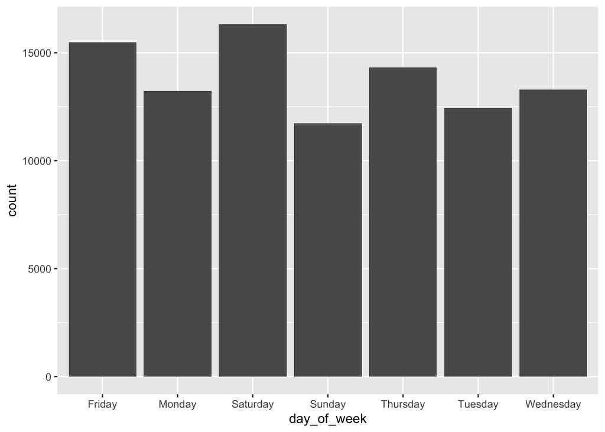

```r
ggplot(data = data_3, aes(x=day_of_week)) + geom_bar()
```

Jueves, Viernes y Sábado son los días mas populares para salir con la bicicleta.